# matplotlib初级教程（Intro to pyplot）

#### scatter()绘制散点图

函数原型：`matplotlib.pyplot.scatter(x, y, s=None, c=None, marker=None, cmap=None, norm=None, vmin=None, vmax=None, alpha=None, linewidths=None, verts=None, edgecolors=None, *, data=None, **kwargs)`  
参数说明：  
**x,y**参数：array_like, shape (n, )，输入数据，x代表点的x轴坐标，y代表点的y轴坐标，n表示点的个数  
**s**参数：scalar or array_like, shape (n, ), optional，点的尺寸，单位为point，size in point^2,譬如3表示点的尺寸为3 point * 3 point，Default is rcParams['lines.markersize']^2.  
**c**参数：color, sequence, or sequence of color, optional，用于描述点标记的颜色，可能的值为：

- 单一的颜色格式字符串（A single color format string.）
- 长为n的颜色序列（A sequence of color specifications of length n.）
- 使用cmap和norm映射到颜色的长为n的数字序列（A sequence of n numbers to be mapped to colors using cmap and norm.）
- 一个形如(n,3)或(n,4)的二维数组，其中行为RGB或RGBA（A 2-D array in which the rows are RGB or RGBA.）

注意：如果要为所有点指定相同的RGB或RGBA，应使用形为(1,3)或(1,4)的二维数组；c参数缺省为None，在这种情况下，点标记的颜色由color, facecolor or facecolors决定，如果这些也没有指定或为None，则点的颜色 is determined by the next color of the Axes' current "shape and fill" color cycle. This cycle defaults to rcParams["axes.prop_cycle"]（不明白）.  
**marker**参数：MarkerStyle, optional，标记样式。标记可以是类的实例，也可以是特定标记的文本速记。默认为“无”，在这种情况下，它采用rcparams[“scatter.marker”]="o"（圆点标记）。有关标记样式的详细信息，请参见markers。  
**cmap**参数：Colormap, optional, default: None，Colormap实例或注册的颜色映射名称。只有当c参数是一个浮点数组时，才使用cmap。如果没有，则默认为rc image.cmap。  
**norm**参数：Normalize, optional, default: None，颜色映射过程中的标准化操作，参见pcolor()  
**vmin,vmax**参数：scalar, optional, default: None，参见pcolor()  
**alpha**参数：scalar, optional, default: None，透明度设置  
**linewidths**参数：scalar or array_like, optional, default: None，点标记的边线宽度，注意，默认的边线颜色（edge color）为点的face color。默认宽度为 rcParams lines.linewidth.  
**edgecolors**参数：color or sequence of color, optional, default: 'face'，点标记的边线颜色，可能的值为：

- 'face': 与点的face color一致
- 'none': 不绘制边线
- A matplotib color.

注意：对于未填充的点标记，其edgecolors关键字参数无效，且边线颜色内部强制为'face'  
**kwargs**：其它关键字参数：Collection properties

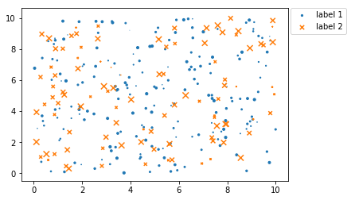

```python
n=200
plt.scatter(np.random.rand(n)*10,np.random.rand(n)*10,s=np.random.rand(n)*10,label='label 1')
n=100
plt.scatter(np.random.rand(n)*10,np.random.rand(n)*10,s=np.random.rand(n)*60,marker='x',label='label 2')
plt.legend(loc=(1.01,0.85)) # 或者plt.gca().legend(['label 1','label 2'])
```

#### errorbar()可以用于描述数据浮动范围、标准差（Standard Deviation）、标准误差（Standard Error）、置信区间（Confidence Intervals）

函数原型：`matplotlib.pyplot.errorbar(x, y, yerr=None, xerr=None, fmt='', ecolor=None, elinewidth=None, capsize=None, barsabove=False, lolims=False, uplims=False, xlolims=False, xuplims=False, errorevery=1, capthick=None, *, data=None, **kwargs)`  
参数说明：  
**x、y**参数同plot(x,y)含义，yerr、xerr见bar()；fmt参数同plot()，设置线条的颜色、点标记、线条类型；ecolor描述error line的颜色；elinewidth描述error line的宽度；capsize参数见bar()；capthick参数是关键字参数markeredgewidth（点标记边线宽）的别名（为了向后兼容，如果给定了mew或markeredgewidth，那么它们将重写（over-ride）capthick。这在将来的版本中可能会改变）；barsabove参数为True时，error line将绘制在plot(x,y,marker)所绘的图像上面，默认是在其下面；  
lolims, uplims, xlolims, xuplims参数：uplims、lolims适用于yerr，xuplims、xlolims适用于xerr。uplims和lolims用于设置是否显示误差范围的上限以及是否显示误差的下限，可以是单个布尔值（适用全部），也可以是一个布尔序列或者0/1序列（逐一设置）；  
errorevery参数：譬如取值为5时，每5个点绘制一次误差线error line，默认为1（对每个点都绘制error line）  
其它关键字参数（所有其它关键字参数都被传递给绘制marker标记的plot函数）：  
譬如以下代码将绘制有着绿色厚边线的大红方形标记：  
`x,y,yerr = rand(3,10) errorbar(x, y, yerr, marker='s', mfc='red', mec='green', ms=20, mew=4)`  
其中mfc、mec、ms和mew是较长属性名markerfacecolor、markeredgecolor、markersize和markeredgewidth的别名。  
当然了，描述marker点标记的属性不止这几种，见文档  
注意：  
除了上述参数外，此函数还可以采用data关键字参数。如果给定了这样的data参数，则以下参数将被`data[<arg>]`替换：'x'、'xerr'、'y'、'yerr'。这样的'data'必须能够通过`data[<arg>]`（譬如data['colors']）的方式访问，并且支持语法：`<arg> in data`

```
<Container object of 3 artists>
```

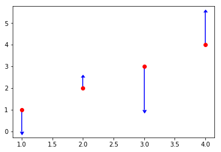

```python
plt.errorbar([1,2,3,4],[1,2,3,4],[1,0.5,2,1.5],fmt='ro',ecolor='b',uplims=[1,0]*2,lolims=[0,1]*2)
```

#### table()绘制表格，一般我们会结合折线图、柱状图等对表格数据进行显性描述（数形结合）

函数原型：`matplotlib.pyplot.table(**kwargs)`  
Call signature:  
`table(cellText=None, cellColours=None, cellLoc='right', colWidths=None, rowLabels=None, rowColours=None, rowLoc='left', colLabels=None, colColours=None, colLoc='center', loc='bottom', bbox=None)`  
参数说明：  
**cellText**参数：形为(m,n)的一个二维数组，给出表格（m行n列）中的全部值类型数据（不含标签）  
**rowLabels**参数：设置行标签，即行名称或字段名序列（长为m）  
**colLabels**参数：设置列标签，即列名称或字段名序列（长为n）  
**cellColours**参数：设置表格（指数据所在格子，不包括行列标签格子）背景色，必须是一个形如(m,n)的数组，即为每一个格子设置颜色 **rowColours**参数：设置行标签所在格子的背景色，长为m的序列  
**colColours**参数：设置列标签所在格子的背景色，长为n的序列  
**cellLoc**参数：表格（特指数据格子）中数据在格子中的位置，默认靠右  
**rowLoc**参数：行标签所在格子中字段的位置设置，默认靠左  
**colLoc**参数：列标签所在格子中字段的位置设置，默认居中  
**colWidths**参数：表格（特指数据所在格子）列宽，只接受列表，长度（大于也合法）等于cellText的1轴长  
**loc**参数：表格在axes轴域中的位置，默认值为'bottom'，即axes底部，参数取值可参见legend()的loc参数（但好像只允许以下取值：{'best': 0, 'bottom': 17, 'bottom left': 12, 'bottom right': 13, 'center': 9, 'center left': 5, 'center right': 6, 'left': 15, 'lower center': 7, 'lower left': 3, 'lower right': 4, 'right': 14, 'top': 16, 'top left': 11, 'top right': 10, 'upper center': 8, 'upper left': 2, 'upper right': 1} ），譬如取值'best'  
**bbox**参数：如何使用？  
函数返回一个matplotlib.table.Table实例，cellText or cellColours参数都是必须被提供的，要实现对表格更精细的绘制，使用Table类，并调用Axes.add_table()方法将其添加到轴域（For finer grained control over tables, use the Table class and add it to the axes with add_table().But how to use?）  
其它用于描述Table属性的关键字参数见[文档](https://matplotlib.org/api/_as_gen/matplotlib.pyplot.table.html#matplotlib.pyplot.table)

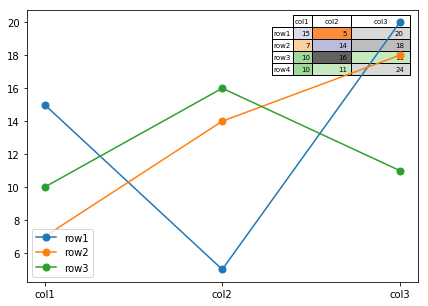

```python
a=np.random.randint(5,25,12).reshape(4,3)
col_labels=['col'+str(i) for i in range(1,a.shape[1]+1)]
row_labels=['row'+str(i) for i in range(1,a.shape[0]+1)]
cmap=plt.get_cmap("tab20c")
plt.figure(figsize=(7,5))
t=plt.table(cellText=a,colLabels=col_labels,rowLabels=row_labels,loc='upper right',
            colWidths=[0.05,0.1,0.15],cellColours=cmap(a))
for i in range(3):
    plt.plot(a[i],marker='o',markersize=7,label='row'+str(i+1))
plt.xticks([0,1,2],['col1','col2','col3'])
plt.legend(loc='lower left')
```

A [demo](https://matplotlib.org/gallery/misc/table_demo.html#sphx-glr-gallery-misc-table-demo-py) from document  
在过去的5年、10年、20年、50年、100年中因霜冻、飓风、洪水、地震、冰雹造成的损失一览表：

```
Text(0.5,1,'Loss in disaster')
```

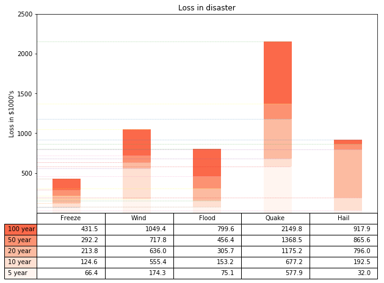

```python
# a demo from document
# 注：data中分别是：第一行为5年、第二行为10年、第三行为20年、第四行为50年、第五行为100年数据
data = [[ 66386, 174296,  75131, 577908,  32015],
        [ 58230, 381139,  78045,  99308, 160454],
        [ 89135,  80552, 152558, 497981, 603535],
        [ 78415,  81858, 150656, 193263,  69638],
        [139361, 331509, 343164, 781380,  52269]]
col_labels = ('Freeze', 'Wind', 'Flood', 'Quake', 'Hail')
row_labels = ['%d year' % x for x in (100, 50, 20, 10, 5)]
# start my practice
data=np.array(table_data)
colors=plt.cm.Reds(np.linspace(0,0.5,len(row_labels))) # len(row_labels)=5，对照Colormap Reference的Reds小彩条，0为起点，1为终点，0.5为中点，本语句作用就是在Reds小彩条起点到中点均匀取5次颜色采样
row_colors=colors[::-1] # 逆序
cell_data=[]
# 绘制柱状图
index=[(2*i+1)/10 for i in range(5)]
width=0.08
bottom=0
for i in range(len(data)):
    plt.bar(index,data[i],width=width,bottom=bottom,color=colors[i])
    for j in range(len(col_labels)):
        plt.axhline(data[i][j]+(bottom if isinstance(bottom,np.ndarray) else [bottom]*len(col_labels))[j],0,(index[j]+width*0.27)/(plt.xlim()[-1]-plt.xlim()[0]),alpha=0.5,color=plt.cm.Set1(np.random.rand()),linestyle='--',linewidth=0.5)
    bottom+=data[i]
    cell_data.append(['%.1f'%(i/1000) for i in bottom])
cell_data=cell_data[::-1]
# 绘制表格
plt.table(cellText=cell_data,rowLabels=row_labels,colLabels=col_labels,rowColours=row_colors)
# others
plt.xticks([])
plt.yticks([500000,1000000,1500000,2000000,2500000],[500,1000,1500,2000,2500])
plt.ylabel("Loss in ${0}'s".format(1000))
plt.gcf().set_figwidth(10)
plt.gcf().set_figheight(6)
plt.title('Loss in disaster')
```

#### 面积图

Call signatures:  
`area(x,y1,[c1],y2,[c2],...)` # 最简单的调用是绘制一条线段：area(x,y,[c])  
`area(x,y1,[c1],...,linestyle='',areaColours=[...])`# linestyle和areaColours为可选关键字参数  
`area(x,y1,[c1],...,linestyle='',areaColours=[...],**kwargs)` # kwargs参数设置Line2D等其它属性，全部传递给plot()

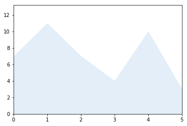

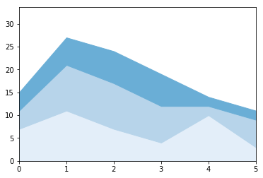

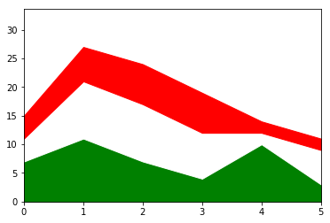

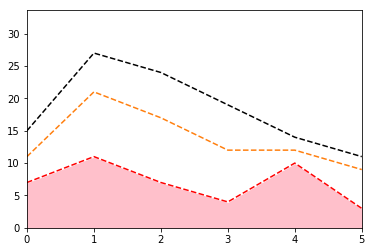

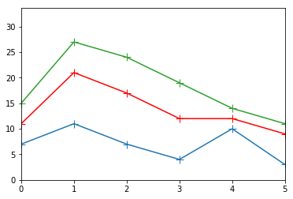

```python
def detection(args):
    '''检验area()位置参数是否合法，以及返回其中颜色参数对应的线条
       索引，此为解析之结果。已知其应为：x,y,[c],[y2,[c2]],...
       省略号表示前一项的无限重复。使用正则表达式：^x(yc?)+$
       进行检验。函数返回三类值：如果参数合法，但没有设置颜色，则
       返回None，否则返回颜色及其对应的线条索引；如果参数不合法，
       则返回False
    '''
    import re
    p=re.compile(r'^x(yc?)+$')
    s=''.join(['x']+['c' if isinstance(i,str) else 'y' for i in args[1:]])
    if not p.search(s):
        return False
    colors=[i for i in args if isinstance(i,str)]
    if len(colors)==0:
        return None
    return [colors,[i for i,e in enumerate(s[1:].split('y')[1:]) if e]] # [颜色序列,颜色对应的线条索引序列]

'''(origin) function detection:
    import re
    p=re.compile(r'^x(yc?)+$')
    s=['c' if isinstance(i,str) else 'y' for i in args[1:]]
    s=['x']+s
    s=''.join(s)
    print(p.search(s))
    r=s[1:].split('y')[1:]
    index=[i for i,e in enumerate(r) if e]
    print(index)
'''

def area(*args,**kwargs):
    '''位置参数说明：
        x: 线条基点的x轴坐标（基点：构成折线段的基本点）
        y: 线条基点的y轴坐标
        c: 线条的颜色
        注1：以上参数勿以键值对形式传递，应严格以位置参数传递
        注2：线条的颜色c参数是可选的
        注3：构成面积图的折线一般具有多条，其x轴坐标一致，可以同时
            给出多条折线的y轴坐标，args参数实际上允许是x和任意数量
            的y,[c]组合，譬如x,y1,y2,c1,y3,c2，其中c1对应y2，c2
            对应y3，未设置的y1颜色同areaColour（linestyle=''即可）
        注4：位置参数args的合法性由detection函数验证，detection()
            函数同时具有解析线条颜色参数设置的作用，即将颜色参数与
            线条一一对应的作用
       关键字参数说明：
        areaColour: 接受一个颜色序列，描述平面坐标上某一线条与位于
            其下方的另一条线条（或者说其在args中位于其前面的线条）
            之间区域填充的颜色，对于最下方或者args中的第一条线条来
            说，是其与x轴之间区域填充的颜色
        其它关键字参数: 其它一切关键字参数都将传递给plt.plot()函数
            ，用于绘制线条
        注5：对detection函数的说明：其具备存在的合理性，对参数列表
            进行合法性检验以及解析，逻辑顺畅并无不妥之处，其次是检
            验参数和允许传递line color也是后添加的，因此额外编写代
            码实现
    '''
    args=list(args)
    # detect the validity of args and interpret it:
    ret=detection(args)
    if ret==False:
        print('参数非法！') # 可以在此处抛出异常
        return 0
    # 如果用户设置了linestyle，全部线条以此为准，如果没有，则默认linestyle=''
    # ，即不进行连线，除非用户设置了某些线条的颜色，对这些线条，linestyle='-'
    # 除了这些用户设置了颜色的线条外，其它全部线条仍linestyle=''
    # 之所以默认不连接线条是为了美观，更重要的是无连接的必要，线条本身可以由不同
    # 的区域填充颜色的轮廓显示出来，但是存在一类特殊情况，假设接连两个区域填充色
    # 都是白色，且未设置线条颜色或设置linestyle，那么线条将彻底不可见，考虑到这
    # 种情况，此时线条linestyle='-'，其颜色由系统自定
    if kwargs.get('linestyle'):
        reset=False # 用户设置了linestyle，就不允许之后在对linestyle进行修改；
    else:
        reset=True # 否则，后面还可以重置linestyle，并且为了方便，先令全部linestyle=''
        kwargs['linestyle']=''
    # 截取填充区域的颜色设置：
    noareas=True if kwargs.get('areaColour')==None else False
    areaColors=kwargs.get('areaColour',plt.cm.Blues([0.1,0.3,0.5]))
    if kwargs.get('areaColour'):
        del kwargs['areaColour']
    # prepare the lines to plot:
    args=[i for i in args if not isinstance(i,str)]
    xy_pack,line_pack=args[:2],[0,args[1]]
    max_y=sum([max(i) for i in args[1:]])
    for i in range(2,2+len(args[2:])):
        xy_pack+=[args[0],args[i]+xy_pack[-1]]
        line_pack+=[xy_pack[-1]]
    # start plot the line,
    plt.subplots()
    lines=plt.plot(*xy_pack,**kwargs)
    # and fill the area.
    for i,e in enumerate(line_pack[1:],1):
        plt.fill_between(args[0],e,line_pack[i-1],color=areaColors[i-1])
    plt.axis([args[0][0],args[0][-1],0,max_y*1.2])
    # set line color and reset line style for each one:
    t=0
    for i,line in enumerate(lines):
        if ret!=None:
            # 如果用户设置了线条颜色，则修改线条颜色：
            if i in ret[1]:
                line.set_color(ret[0][t])
                t+=1
                if reset: # 如果用户设置了当前线条的颜色并且允许重置linestyle，则置linestyle='-'
                    line.set_linestyle('-')
        if not noareas: # 如果没有设置areaColours参数，则（否则存在一个FurtherWarning）：
            # 如果填充区域颜色为白色并且下一填充区域也为白色或者没有下一区域了，同时允许重置linestyle，则置linestyle='-'
            if areaColors[i] in ['w','white'] and (areaColors[i+1] in ['w','white'] if i+1<len(lines) else True) and reset:
                line.set_linestyle('-')

# 我真的是太长时间没有认真编程了，感觉生不如死，满脑袋浆糊了已经，太失败 19/01/17
# test
index=np.arange(6)
np.random.seed(3501)
d1=np.random.randint(2,12,6)
d2=np.random.randint(2,12,6)
d3=np.random.randint(2,12,6)
area(index,d1)
area(index,d1,d2,d3)
area(index,d1,d2,d3,areaColour=['green','w','red'])
area(index,d1,'red',d2,d3,'black',areaColour=['pink','w','w'],linestyle='--')
area(index,d1,d2,'red',d3,areaColour=['w','w','w'],marker='+',markersize=10)
```

#### 雷达图

其实就是线形图的极坐标表示，就此说一下polar()函数，函数本身很简单：

##### polar()绘制极坐标图形

函数原型：`matplotlib.pyplot.polar(*args, **kwargs)`  
all signature:  
`polar(theta, r, **kwargs)`  
和plot()函数一样（意思是，将polar()当作plot()耍，除了plot()的x,y参数替换为theta,r之外，其余相同），支持多个theta, r参数组合，还有格式字符串fmt  
之前咱们不是用极坐标绘制柱状图嘛，先用subplot(projection='polar')准备一个极坐标的画板，然后使用bar()绘制柱状图即可，跟在直角系下的区别也是，将bar()的x,height参数替换为theta,r，仅此而已。同样地，今天要绘制极坐标下的线形图，也可以先用subplot()准备个画板，然后用plot()直接绘制折线完事儿  
其它设置刻度、刻度标记、legend什么的，就跟平时在直角系下一样一样的，坐标系就是一个画板，不影响实际的绘制工作

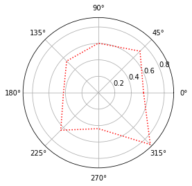

```python
np.random.seed(0)
theta=np.linspace(0,2*np.pi,9)
r=np.random.rand(8)
r=np.append(r,r[0])
plt.polar(theta,r,'r:')
```

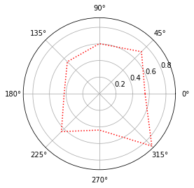

```python
np.random.seed(0)
theta=np.linspace(0,2*np.pi,9)
r=np.random.rand(8)
r=np.append(r,r[0])
plt.subplot(projection='polar')
plt.plot(theta,r,'r:')
```

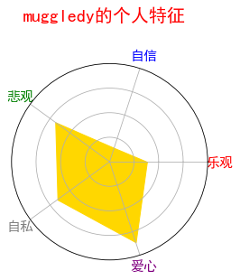

```python
# 雷达图
label=['乐观','自信','悲观','自私','爱心']
n=len(label)
theta=np.linspace(0,2*np.pi,n+1)
r=np.random.rand(n) # r取值0-1
r=np.append(r,r[0])
plt.rcParams['font.sans-serif']=['SimHei'] # 使支持中文显示
plt.polar(theta,r,linestyle='')
labels_leida=plt.xticks(theta[:-1],label,fontsize=15,color='blue') # 此处似乎只能为全部标签设置同一颜色，现在要求为每一个label设置一种颜色
plt.ylim(0,1) # 因为r取值0-1，所以ylim(0,1)，不做如此设置会导致出现重复轴标签，嗯，你自己尝试一下就知道了
#plt.thetagrids()
plt.fill_between(theta,r,color='gold')
plt.suptitle('muggledy的个人特征',x=0.5,y=1.1,color='red',fontsize=20)
plt.yticks(np.linspace(0,1,5),[]) # 不显示y轴即r轴标签，非禁用y轴刻度
# 为每一个label设置颜色，须知，xticks()返回的是一个二元列表，第一个元素是刻度序列，第二个元素是刻度标签序列，也就是我们要的对象（Text），在对象上调用set_color()即可：
labels_leida[1][0].set_color('red')
labels_leida[1][2].set_color('green')
labels_leida[1][3].set_color('gray')
labels_leida[1][4].set_color('purple')
```

#### hist()绘制直方图（histogram），可以用于观察样本（连续性随机变量）的分布情况

函数原型：`matplotlib.pyplot.hist(x, bins=None, range=None, density=None, weights=None, cumulative=False, bottom=None, histtype='bar', align='mid', orientation='vertical', rwidth=None, log=False, color=None, label=None, stacked=False, normed=None, *, data=None, **kwargs)`  
直方图由诸多紧密相连的bin（直译“箱子”）组成，每个bin为长方形的条状，其宽度总是表示样本落入的某一值区域范围（或称“组”group），高度可能表示落入此区域的样本数量（频数），也可能表示样本落入此区域的概率密度，具体表示谁得看density参数或normed参数的设置。  
参数说明：  
**x**：样本数据，可以包含多个样本集合，同一样本集合的bin颜色是相同的，不同样本集合的bin颜色不相同  
**bins**：可以是标量、数值序列或字符串。单个标量表示bin的个数n，设全部样本的值范围为s，那么s将被均匀分配给这n个bin，即每个bin的宽度相同，且等于s/n。若想自定义每个bin的宽度，即不等间隔的直方图，则使用数值序列，这个序列中的元素为：[第一个bin的左端刻度，第一个bin的右端刻度，第二个bin的右端刻度，...，第n个bin的右端刻度]（这个刻度序列总是作为hist()的第二个返回值返回），第n个bin的右端刻度~第一个bin的左端刻度即为全部样本的取值范围。如果使用Numpy 1.11或更新版本，还可以选择描述不同分箱策略的字符串值，例如'auto'，'sturges'，'fd'，'doane'，'scott'，'rice'，'sturges'或'sqrt'，见numpy.histogram。  
**range**：一个元组，指定样本的上下界（阈值），丢弃非此范围内的样本  
**density**：默认为False。当其为True时，直方图的总面积为1，每个bin的高度表示“概率密度”（很容易理解，假设bin的宽度很小很小，我们用一个函数来对其进行拟合，由于总面积为1，即该函数上的积分值为1（分布函数），因此其表示的是“概率密度函数”，bin的高度相应的也就是概率密度了），每个bin的面积表示变量落在此间区域的概率。当density取值False时，bin的高度表示落入此间区域的样本频数，将全部bin的高度求和即得总样本容量（总样本个数）。该参数取代了旧版本的normed参数，目前两个参数可以任取其一进行设置，推荐使用density。  
**weights**：为每一个样本设置权重，默认都相同。数组形状和x相同。An array of weights, of the same shape as x. Each value in x only contributes its associated weight towards the bin count (instead of 1). If normed or density is True, the weights are normalized, so that the integral of the density over the range remains 1.（此处不太明白）  
**cumulative**：缺省为False，如果为True，则直方图中每个bin的高度为该bin所在区域样本频数加上较小值区域内的所有bin的全部样本频数之和。最后一个bin给出了样本的总数。如果normed或density参数也为True，则将直方图归一化，使得最后一个bin高度等于1，实际上若对此时的直方图进行拟合，得到的曲线就是“分布函数”。If cumulative evaluates to less than 0 (e.g., -1), the direction of accumulation is reversed. In this case, if normed and/or density is also True, then the histogram is normalized such that the first bin equals 1.（为什么会小于0？）  
**bottom**：设置每个bin的底部基线，默认为0。为单个标量时，表示适用于全部bin  
**histtype**：{'bar', 'barstacked', 'step', 'stepfilled'}，要绘制的直方图的类型：

- 'bar'（缺省值）是传统的条形直方图。如果给出多个样本数据集，它们将并排排列
- 'barstacked'也是一种条形直方图，多个样本数据集将堆叠在一起呈现
- 'step'生成一个默认未填充的线图
- 'stepfilled'生成一个默认填充的线图

**align**：{'left', 'mid', 'right'}，一般我们总是选择'mid'，其亦为缺省值  
**orientation**：{'horizontal', 'vertical'}，如果取值'horizontal'，那么barh()将被使用以绘制条形图（直方图本质就是条形图）  
**rwidth**：直方图bin的宽度百分比，默认值为1，相邻bin之间紧密相连，没有空隙。假如我们取值0.5，则bin的宽度缩小为原来的一半，将导致相邻bin之间留有较大的空隙  
**color**：单个颜色或颜色序列，必须与样本数据一一匹配，即有多少个数据集，就要设置多少个颜色配对（假如我们希望设置某一数据集颜色的话）  
**edgecolor**：bin的边界颜色，如果不设置该值，则不同的bin之间没有明显的界限区分，当相邻两个bin的高度一致时，将会造成视觉干扰，所以一般都是要设置该参数的  
**log**：设置对数刻度，默认为False  
**label**：为每一个样本数据集设置标签（供legend()使用）  
**stacked**：多个数据集时是否堆叠显示，允许与histtype参数同时使用，因为histtype为'step'时，多个数据集是重叠显示的线框图，当指定stacked取True时，多个数据集将变成以堆叠形式显示的线框图，当histtype取'bar'时，若stacked为True，则堆叠显示，即stacked优先级更高  
**normed**：功能同density参数，推荐使用替代它的density  
返回值：

- n : array or list of arrays，返回全部数据集的直方图高度序列，譬如：[data1_bins_height,data2_bins_height,...]（多个数据集，每个data_bins_height形如后面的序列）或[bin1_height,bin2_height,...]（单个数据集）
- bins : array，刻度序列（不同数据集具有相同的刻度序列），见bins参数
- patches : list or list of lists，直方图中的全部bin对象

直方图与条形图（柱状图）的区别：  
首先，条形图是用条形的长度表示各类别频数的多少，其宽度（表示类别）则是固定的  
直方图是用面积表示各组频数的多少，矩形的高度表示每一组的频数或频率，宽度则表示各组的组距，因此其高度与宽度均有意义  
其次，由于分组数据具有连续性，直方图的各矩形通常是连续排列，而条形图则是分开排列  
最后，条形图主要用于展示分类数据，而直方图则主要用于展示数据型数据

```
Text(101,0.5,'分值')
```

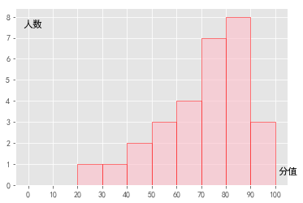

```python
# 现在有一组数据，根据全班同学数学成绩绘制的直方图，数据是我自己随意捏造的，我们以10分作为一组group（一百分总共划分为10组），观察落入不同group的分布情况
data=[25,33,45,46,50,54,56,61,61,65,69,73,77,77,78,78,78,79,80,82,82,83,84,87,87,88,92,92,95]
bins=[i*10 for i in range(11)]
def cc(arg):
    '''Shorthand to convert 'named' colors to rgba format at 60% opacity.'''
    return mcolors.to_rgba(arg, alpha=0.6)
color=cc('pink')
plt.hist(data,bins,edgecolor='red',color=color,rwidth=1,) # 此时图中bin的高度是（成绩）样本的频数，即分数落在某一group（分值区域）的人数。由于普遍规律是（较大样本下）：
# 学生的成绩服从正态分布，因此当取density为True时，直方图应该能够很好地拟合出服从(mu,sigma)的正态概率密度函数，当然了，肉眼直接看就能看出大概情况，中间高两头低嘛
plt.xticks(bins,bins)
plt.annotate('人数',(-2,7.5),fontsize=12)
plt.annotate('分值',(101,0.5),fontsize=12)
```

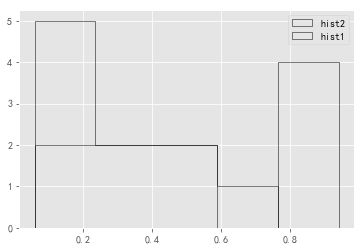

```python
np.random.seed(20190123)
data=np.vstack([np.random.rand(10),np.random.rand(10)])
plt.hist(list(data),5,density=False,edgecolor='k',color=[mcolors.to_rgba('red', alpha=0.1),'purple'],label=['hist1','hist2'],histtype='step') #
plt.legend()
```

##### 构造符合正态分布($\mu$,$\sigma$)的数据集X

待求一组随机样本X，满足：$X\sim N(\mu,\sigma)$  
根据标准化：$\frac{X-\mu}{\sigma}\sim N(0,1)$  
设：$Z=\frac{X-\mu}{\sigma}$，即有：$Z\sim N(0,1)$，$X=\sigma Z+\mu\sim N(\mu,\sigma)$  
又知`np.random.randn(n)`可以生成指定数量n的一组随机样本，其符合标准正态分布（$Z$），于是有：  
$\sigma *np.random.randn(n)+\mu\sim N(\mu,\sigma)$

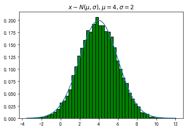

```python
# 产生一组符合正态分布（mu,sigma）的样本，并对其拟合
mu=4
sigma=2
x=np.random.randn(10000)*sigma+mu # 样本要足够大，才能显示出其遵循的分布规律
n,bins,_=plt.hist(x,50,density=True,color='g',edgecolor='k') # 此时bin高度为概率密度
plt.title('$x\sim N(\mu,\sigma),\mu=4,\sigma=2$')
# add a 'best fit' line:
y=scipy.stats.norm.pdf(bins,mu,sigma)
plt.plot(bins,y)
```

The documentation tells us about matplotlib.mlab.normpdf, and do not use this function any more, use [scipy.stats.norm.pdf](https://docs.scipy.org/doc/scipy/reference/generated/scipy.stats.norm.html) instead.  
Hence a previous code like:

```
import matplotlib.mlab as mlab
import numpy as np

x = np.linspace(-3,3)
mu = 0
sigma = 1
y = mlab.normpdf(x, mu, sigma)
```

should now read:

```
import numpy as np
import scipy.stats

x = np.linspace(-3,3)
mu = 0
sigma = 1
y = scipy.stats.norm.pdf(x, mu, sigma)
```

#### contour()绘制等高线图

原型：`matplotlib.pyplot.contour(*args, data=None, **kwargs)`  
Call signature：`contour([X, Y,] Z, [levels], **kwargs)`  
另外还有`contourf()`函数，它和`contour()`的使用一模一样（对同一图像，它们的参数调用应该是一致的），两者分别绘制填充颜色的等高线图以及等高线图  
`X`和`Y`都必须是二维的，同`Z`的形状，一般它从`meshgrid()`产生，这意味着我们所绘的是一个二元函数，`Z=f(X,Y)`。`levels`可以是整数也可以是一维数组，如果是整数（`n`），表示等高线的数量（`n+1`，有`n`个均匀间隔），如果是数组（元素是递增的），表示等高线的位置（这个描述几乎不能理解，实际上等高线是有数值的，就是某些处于同一高度的点`(x,y)`所构成的一条连续曲线（想象拿一个锋利的平面去切割一座山，得到的切面轮廓线），譬如当你指定`levels`的值为`[3,6]`，这意味着只绘制两条等高线，两条线的高度分别为3和6），其他参数（譬如颜色、透明度、色域、线条属性等）交给`kwargs`，见[文档](https://matplotlib.org/api/_as_gen/matplotlib.pyplot.contour.html)。下面看一下具体使用：

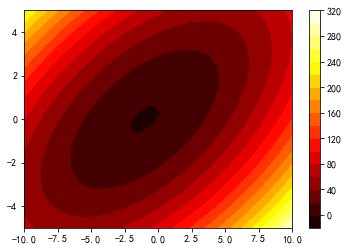

```python
#  y = x^2 – 2*x*y + 3*y^2 + 2*x – 2*y
x=np.linspace(-10,10,40)
y=np.linspace(-5,5,20)
X,Y=np.meshgrid(x,y)
Z=X**2-2*X*Y+3*Y*Y+2*X-2*Y
# 绘制填充颜色的等高线图
plt.contourf(X, Y, Z, 15, cmap = plt.cm.hot)
plt.colorbar()
```

[output not shown]

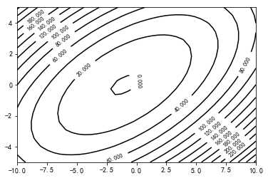

```python
# 绘制等高线，当图形中只使用一种颜色的时候，会使用虚线来表示负数，实线表示正数
C = plt.contour(X, Y, Z, 15, colors = 'black')
# 显示各等高线的数据标签
plt.clabel(C, inline = True, fontsize = 8)
```

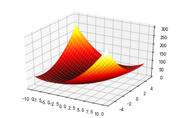

```python
#%matplotlib notebook
fig = plt.figure()
ax = fig.gca(projection='3d')
ax.plot_surface(X, Y, Z, cmap = plt.cm.hot)
```

### 常见曲线绘制

#### 心形线

最简单的就是极坐标的那种了，但是太胖了点，下面是我搜到的其他的画法，纯粹凑个热闹，都可化显函数作图，下面两个我不是很满意，如果有兴趣，可以使用贝塞尔方程绘制心形线，参见"patches与path.ipynb"#心形线

$f(x)=-tan(\sqrt[2]{1-|x|^\frac{3}{2}})+\frac{\pi}{2}$  
$g(x)=\sqrt[2]{\frac{1}{4}-(x+\frac{1}{2})^2}+\frac{\pi}{2}$  
$h(x)=\sqrt[2]{\frac{1}{4}-(x-\frac{1}{2})^2}+\frac{\pi}{2}$

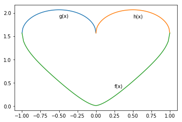

```python
x=np.linspace(-1,0,100)
y=np.sqrt(np.fabs(0.25-np.power(x+0.5,2)))+0.5*np.pi
plt.plot(x,y)
x=np.linspace(0,1,100)
y=np.sqrt(np.fabs(0.25-np.power(x-0.5,2)))+0.5*np.pi
plt.plot(x,y)
x=np.linspace(-1,1,100)
y=0.5*np.pi-np.tan(np.sqrt(np.fabs(1-np.power(np.fabs(x),1.5))))
plt.plot(x,y)
plt.annotate('g(x)',(-0.5,1.9))
plt.annotate('h(x)',(0.5,1.9))
plt.annotate('f(x)',(0.25,0.4))
```

$x^2+(y-\sqrt[3]{x^2})^2=1$  
化为参数方程：  
$\begin{cases} x=sin(t) \\ y-\sqrt[3]{x^2}=cos(t) \end{cases}$

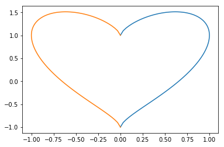

```python
t=np.linspace(0,np.pi,100)
x=np.sin(t)
y=np.cos(t)+np.power(x,2.0/3)
plt.plot(x,y)
plt.plot(-x,y)
```

#### 阿基米德螺线

极坐标：$p=a\theta$

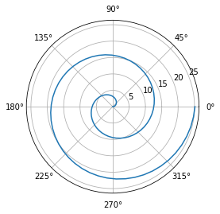

```python
a=2 # 取a为2
theta=np.linspace(0,4*np.pi,100)
p=a*theta
plt.polar(theta,p)
```

### 动态图绘制

#### 交互式

以线形图为例，无非就是画点、连线，一气呵成，要实时动态地绘制线形图，就是将n个点的一次性连接拆分成n-1次两点的连线（当然了你也可以每次连接更多个点），本来n个点的连接，用一个plot()就完事，现在需要n-1次plot()，每次需要知道的就是起点和终点的位置坐标，然后连起来，起点是上一次plot()的终点，所以我们要做的就是产生下一次的点的位置，就是需要一个不断产生图像在前进方向轨迹上的点的坐标数据的生成器

##### 绘制 y=sinx的图像

见./matplotlib/DB/demo/jupyter中交互式动图展示.ipynb 和 交互式动图脚本(一元函数).py

```
def g_points(fun,start,end,accuracy=30,n=5):
    '''
    功能：一元显函数轨迹点坐标生成器
    参数说明：fun: 函数关系，譬如一个lambda表达式
             start: x轴起点
             end: x轴终点（start和end是函数f自变量x的取值范围，闭区间）
             accuracy: 精细程度，单位长度内所绘点的个数，一个大于等于1的正整数，控制线形图的光滑度
             n: 一次plot绘制的点的个数，一个大于1的正整数（适当调高accuracy和调小n可以延长动画）
    '''
    n=int(np.fabs(n))
    if n==1: return
    accuracy=int(np.fabs(accuracy))
    if accuracy==0: return
    counts=int((end-start)*accuracy+1)
    x=np.linspace(start,end,counts)
    t=0
    while True:
        try:
            x[t]
        except:
            break
        yield [x[t:t+n],fun(x[t:t+n])]
        t+=(n-1)

for x,y in g_points(lambda x:np.sin(x),0,4*np.pi,accuracy=5):
    plt.plot(x,y)
    plt.pause(0.001) # Pause for interval seconds.
```

使用**animation模块**绘制动态图，见./matplotlib之animation.ipynb

### 注意事项

如果创建了许多个图像（figure），你需要知道一个事实：除非使用close()方法显式地关闭，否则图像所占用的内存是不会被释放的。通过删除对对象的（外部）引用或者使用窗口管理器关闭屏幕上显示图形的窗口都不足以使得内存被释放，因为直至close()被调用，pyplot模块内部将会始终保持对图像的内部引用。

## FAQ（常见问题解答）

Here are many frequently asked questions, you may really benefit from it.

### 使用何种风格的编程方式，MATLAB or object-oriented？

pyplot分别提供了函数式编程和面向对象编程的接口api，可以说，这是两种编程风格俱不可磨灭的最佳印证。函数式表达简洁（就像是在敲命令）但是过程稍微有点不清晰，对于初学者，有可能困惑于正在操作的figure或plot是谁以及如何在不同的figure和plot之间自由切换的问题，可见其灵活性也大打折扣。对象式操作过程明晰但是写出来的代码相较于函数式显得冗长，需要不断返回待操作的对象以及为其命名（还得抓脑袋想出个有意义的名字）。推荐以MATLAB风格为主绘图，辅以面向对象。官方明确表示：面向对象更适合于“复杂”绘图（The object-oriented API is recommended for more complex plots.），但要想真正学透彻matplotlib，必须深入面向对象。（另外还存在第三种方式，导入pylab模块，明确不推荐）

### 交互式绘图

jupyter notebook或ipython中默认都是交互式绘图，在python脚本中，你需要手动开启，使用plt.ion()和plt.ioff()开启和关闭interactive mode（交互模式）。两者的区别在于，执行图像绘制命令如plot()之后图像是否显示，以及当图像显示之后能否动态实时地修改。非交互模式必须使用plt.show()才能显示图像，且后续无法修改，只能推倒重新来过。

### 绘图时不能显示中文

中文显示成小方格，修改配置即可  
解决方案：

- 动态设置：  
  `plt.rcParams['font.sans-serif']=['SimHei']` # for Chinese characters  
  `plt.rcParams['axes.unicode_minus']=False` # 解决负号'-'显示为方块的问题
- 使用matplotlib下的字体管理器：  
  `myfont=matplotlib.font_manager.FontProperties(fname='.../SimHei.ttf')` # 字体[下载](https://www.fontpalace.com/font-details/SimHei/)  
  然后在绘图函数中将其传递给fontproperties参数，譬如：  
  `plt.title('函数图像',fontproperties=myfont,fontsize=32)`
- 修改配置文件（一劳永逸）：  
  找到配置文件**matplotlibrc**，其位于matplotlib安装包下的`mpl-data`文件夹内（执行 `matplotlib.matplotlib_fname()` 将会获得配置文件的全路径）  
  在文件中修改以下配置：  
  `font.family : sans-serif`  
  `font.sans-serif : SimHei, Bitstream Vera Sans, Lucida Grande, Verdana, Geneva, Lucid, Arial, Helvetica, Avant Garde, sans-serif`  
  即将我们下载的SimHei字体设为首项，然后将SimHei.ttf文件放到`mpl-data/fonts/ttf`文件夹下即可

推荐使用动态设置

muggledy 2019/1/8~2019/1/20 初级教程基本整理完毕 1.0